# Individual tree detection using lidR

Sarah Kopitz

February 2026

# LiDAR ITD

## set up

```r
# load packages
library(lidR)
library(terra)
```

## create las object and normalize

```r
# Creates a catalog for all raw LiDAR tiles
cat_mkrf <- readLAScatalog("data/LAS")

# inspect the catalog
las_check(cat_mkrf)

# Examine a single tile to see if duplicates exist
tile_1_mkrf <- readLAS("data/LAS/MKRF_Tile1.las")
las_check(tile_1_mkrf)


## Clean up the data - remove duplicates

#Set the output directory for the filtered .las data
opt_output_files(cat_mkrf) <- paste("data",
                      "/Filtered/filtered_mkrf_{ID}", sep = "")

#remove duplicate points and speed up processing
cat_mkrf <- filter_duplicates(cat_mkrf)

#read filtered .las into LAScatalog
filtered_cat_mkrf <- readLAScatalog("data/Filtered")


## Create DEM

#Create DEM
dem_allLAS_mkrf <- rasterize_terrain(filtered_cat_mkrf,
                                     2, # 2 meter spatial resolution
                                     tin())   # interpolation method


## Normalize catalog

# Define output folder for normalized tiles
opt_output_files(filtered_cat_mkrf) <- paste("data",
                      "/Normalized/norm_mkrf_{ID}", sep = "")

# Normalize all tiles using DEM
# This subtracts the ground elevation from every point in the catalog
norm_cat_mkrf <- normalize_height(filtered_cat_mkrf, dem_allLAS_mkrf)
```

```r
#read normalized las into catalog to continue processing
norm_cat_mkrf <- readLAScatalog("data/Normalized")

#add LAScatalog enginge option to filter undersired data points
opt_filter(norm_cat_mkrf) <- '-drop_z_below 0 -drop_z_above 65'
```

## Plot Extraction

```r
#read 'Plot_Table.csv'
plot_table <- read.csv("data/Lab4_Plots.csv")

# Define plot radius (Diameter 154m / 2 = 77m)
radius <- 77

#for loop to extract multiple plots
#run the loop until i = the number of rows in 'plot_table' (20)
for(i in 1:nrow(plot_table)){

  #extract plot center
  plot_cent <- c(plot_table$X[i], plot_table$Y[i])

  #clip plot from norm_cat_las
  plot_las <- clip_circle(norm_cat_mkrf, plot_cent[1], plot_cent[2], radius)

  #output directory as string
  output_file <- paste("data/Plots/MKRF_Plot_", i, ".las", sep = "")

  #write'MKRF_Plot_i' to output dir.
  writeLAS(assign(paste("MKRF_Plot_", i, sep = ""), plot_las), output_file)
}
```

## Detect Individual Trees using a Point Cloud

```r
# individual tree segmentation using Li et al 2012 on PLOT 1
plot1_li2012 <- segment_trees(MKRF_Plot_1,         # Plot 1
                             li2012(dt1 = 1.5,     # theshold number 1
                                    dt2 = 2,       # threshold number 2
                                    R = 2,         # search radius
                                    Zu = 15,       # point elevation
                                    hmin = 2,      # min height of detected tree
                                    speed_up = 10)) # max crown radius

# individual tree segmentation using Li et al 2012 on PLOT 2
plot2_li2012 <- segment_trees(MKRF_Plot_2, li2012(dt1 = 1.5, dt2 = 2,
                                 R = 2, Zu = 15, hmin = 2, speed_up = 10))
# individual tree segmentation using Li et al 2012 on PLOT 3
plot3_li2012 <- segment_trees(MKRF_Plot_3, li2012(dt1 = 1.5, dt2 = 2,
                                 R = 2, Zu = 15, hmin = 2, speed_up = 10))
# individual tree segmentation using Li et al 2012 on PLOT 4
plot4_li2012 <- segment_trees(MKRF_Plot_4, li2012(dt1 = 1.5, dt2 = 2,
                                 R = 2, Zu = 15, hmin = 2, speed_up = 10))

plot(plot1_li2012, color = "treeID")
plot(plot2_li2012, color = "treeID")
plot(plot3_li2012, color = "treeID")
plot(plot4_li2012, color = "treeID")
```

### Questions and Screenshots

**Question 1:** In what type of forest stand do Li et al., 2012 suggest their algorithm is successful? Do the four plots you extracted match this description?

**Answer:**

Li et al. (2012) suggest their algorithm is most successful in mixed conifer stands. Plot 1 fits this description well because the trees are clearly separated, while Plots 2–4 only partially match because more dense canopy conditions make individual tree separation more difficult.

**Question 2:** Which part of the tree do Li et al., 2012 begin their point classification with? Why do they do this?

**Answer:**

They use a top-to-bottom approach to classify points, starting with the highest point as the “seed point.” They do this because the top of the canopy (especially in conifers) is more distinct and usually has more horizontal separation from neighbouring trees than the lower canopy, where crowns overlap more making individual crowns harder to separate.

**Question 3:** Define the speed_up argument in the li2012 algorithm.

**Answer:**

The speed_up parameter limits how far the algorithm searches for points when segmenting an individual tree. Points that are farther than this distance from the current tree being grown are ignored. This speeds up processing without changing the segmentation results as long as the value is larger than the actual crown size.

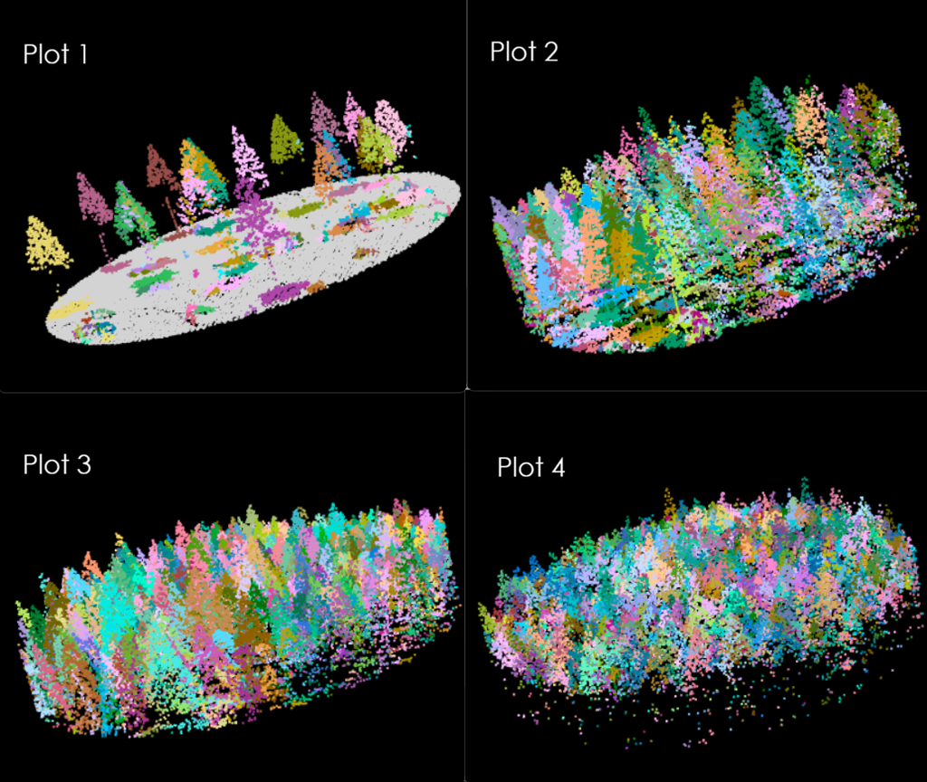

Screenshot 1: Plots 1, 2, 3 and 4 segmented with li2012 and colored by treeID

## Detect Individual Trees using a CHM

```r
## Create CHM

# create CHM of plot 1 using 0.5 meter resolution
chm_plot1 <- rasterize_canopy(MKRF_Plot_1,  # input lascatalog
                        0.5,  # 0.5 meter spatial resolution
                        pitfree(      # algorithm
                          thresholds = c(0,10,20,30),
                          max_edge = c(0, 1),
                          subcircle = 0.2))   # 20 cm radius
# find tree tops in plot 1
tops_plot1 <- locate_trees(chm_plot1, lmf(ws = 5, hmin = 2))

# plot Plot 1 CHM with identified tree tops overlaid
plot(chm_plot1, main = "Plot 1 CHM with Detected Treetops")
plot(tops_plot1, add = TRUE, pch = 3, col = "red", cex = 0.5)

# individual tree segmentation using Dalponte 2016 for Plot 1
plot_1_dal <- segment_trees(MKRF_Plot_1,
                            dalponte2016(chm_plot1, tops_plot1,
                                         th_tree = 2,
                                         th_seed = 0.45,
                                         th_cr = 0.55,
                                         max_cr = 10))
# plot 3D of ITS using Dalponte 2016 for Plot 1
plot(plot_1_dal, color = "treeID")
```

```r
## CANOPY HEIGHT MODELS (CHM) ##
# create CHM of plot 2 using 0.5 meter resolution
chm_plot2_05 <- rasterize_canopy(MKRF_Plot_2,  # input lascatalog
                        0.5,  # 0.5 meter spatial resolution
                        pitfree(      # algorithm
                          thresholds = c(0,10,20,30),
                          max_edge = c(0, 1),
                          subcircle = 0.2))   # 20 cm radius

# create CHM of plot 2 using 2 meter resolution
chm_plot2_2 <- rasterize_canopy(MKRF_Plot_2,  # input lascatalog
                        2,  # 2 meter spatial resolution
                        pitfree(      # algorithm
                          thresholds = c(0,10,20,30),
                          max_edge = c(0, 1),
                          subcircle = 0.2))   # 20 cm radius

# create CHM of plot 2 using 4 meter resolution
chm_plot2_4 <- rasterize_canopy(MKRF_Plot_2,  # input lascatalog
                        4,  # 4 meter spatial resolution
                        pitfree(      # algorithm
                          thresholds = c(0,10,20,30),
                          max_edge = c(0, 1),
                          subcircle = 0.2))   # 20 cm radius

# create CHM of plot 2 using 10 meter resolution
chm_plot2_10 <- rasterize_canopy(MKRF_Plot_2,  # input lascatalog
                        10,  # 10 meter spatial resolution
                        pitfree(      # algorithm
                          thresholds = c(0,10,20,30),
                          max_edge = c(0, 1),
                          subcircle = 0.2))   # 20 cm radius


# Set up a 2x2 plotting grid
par(mfrow = c(2,2))
# Plot each resolution
plot(chm_plot2_05, main = "Resolution: 0.5m")
plot(chm_plot2_2,  main = "Resolution: 2m")
plot(chm_plot2_4,  main = "Resolution: 4m")
plot(chm_plot2_10, main = "Resolution: 10m")
# Reset the plotting window to normal (1x1)
par(mfrow = c(1,1))


# plot 2 for 0.5m resolution
# find tree tops in plot 2 at 0.5 meter CHM resolution
tops_plot2_05 <- locate_trees(chm_plot2_05, lmf(ws = 5, hmin = 2))
# plot 2 for 0.5m resolution - individual tree segmentation
plot_2_dal <- segment_trees(MKRF_Plot_2,
                            dalponte2016(chm_plot2_05, tops_plot2_05,
                                         th_tree = 2,
                                         th_seed = 0.45,
                                         th_cr = 0.55,
                                         max_cr = 10))
# plot 2 for 0.5m resolution
plot(plot_2_dal, color = "treeID")


# plot 2 for 2m resolution
# find tree tops in plot 2 at 2 meter CHM resolution
tops_plot2_2 <- locate_trees(chm_plot2_2, lmf(ws = 5, hmin = 2))
# plot 2 for 2m resolution - individual tree segmentation
plot_2_dal_2 <- segment_trees(MKRF_Plot_2,
                            dalponte2016(chm_plot2_2, tops_plot2_2,
                                         th_tree = 2,
                                         th_seed = 0.45,
                                         th_cr = 0.55,
                                         max_cr = 10))
# plot 2 for 2m resolution
plot(plot_2_dal_2, color = "treeID")
```

### Questions and Screenshots

**Question 4:** What is a key advantage of the tree-centric approach over existing area-based methods according to Dalponte and Coomes 2016?

**Answer:**

A key advantage is that the tree-centric approach has similar accuracy to field inventory models. Area based methods are not able to be directly connected to field measurements because they are based on averaging tree information within plots.

**Question 5:** Explain the difference between the th_seed and th_cr arguments of the dalponte2016 algorithm.

**Answer:**

th_seed is Growing Threshold 1, where a pixel is added to a region if its height is greater than the tree height multiplied by this value (default 0.45). th_cr is Growing Threshold 2, where a pixel is added to a region if its height is greater than the current mean height of the region multiplied by this value (default 0.55). The difference is that th_seed is tied to the initial tree height and is used when growing the crown from the seed point, while th_cr is using the region’s current mean height and is used as the crown expands outward.

**Question 6:** If you had to select a spatial resolution to conduct segmentation at for the entire MKRF, what would it be? Justify your answer.

**Answer:**

I would use 0.5 m resolution for the entire MKRF because the individual crowns are the most identifiable at 0.5m (Screenshot 3). Individual tree segmentation is looking for the highest point (the treetop), and at more coarse resolutions that top starts to blur, so you don’t get as clear of a picture of the real tree top. 0.5 m could be a bit computationally intense for the whole MKRF, so 2 m runs faster while still allowing individual trees to be detected (Screenshot 4).

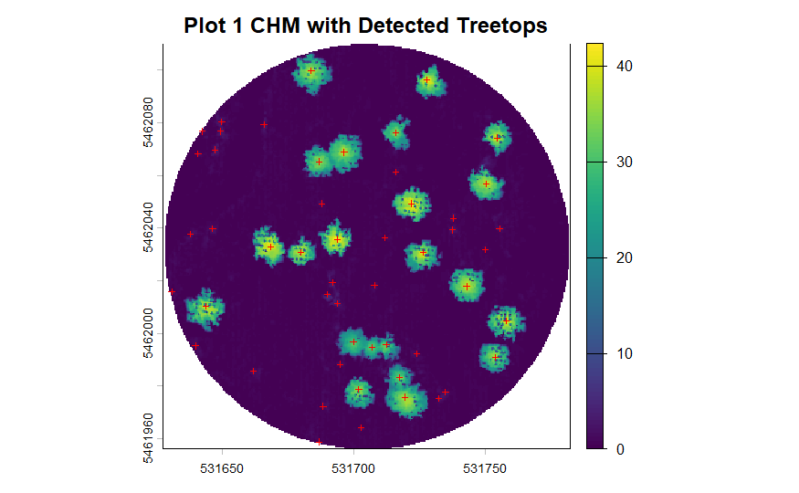

Screenshot 2: CHM of Plot 1 using dalponte2016 with treetops overlaid.

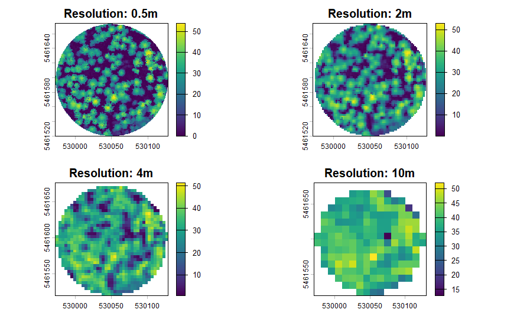

Screenshot 3: CHMs of Plot 2 at 0.5m, 2m, 4m and 10m resolution using dalponte2016.

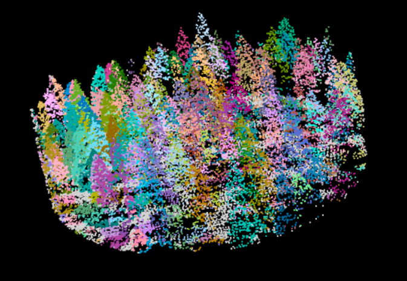

Screenshot 4: Output segmentation of Plot 2 with 2m resolution using dalponte2016.